# A2 - Anàlisi estadística I

Xavier Maltas

Abril 2022

# 1 Lectura del fitxer i preparació de les dades

Realitzarem la càrrega de l’arxiu que conté el conjunt de dades.

```r
cens <- read.csv("CensusIncome_clean.csv", sep=",")
head(cens)
```

```
##   CS_ID age     workclass education_num marital_status  relationship
## 1   CS1  50 Self-Employed            13              M Not-in-family
## 2   CS2  38       Private             9              D       Husband
## 3   CS3  53       Private             7              M Not-in-family
## 4   CS4  28       Private            13              M       Husband
## 5   CS5  37       Private            14              M          Wife
## 6   CS6  49       Private             5              M          Wife
##     occupation  race gender hours_per_week income     education_cat
## 1 White-Collar White      m           13.5  52.00     Universitaria
## 2  Blue-Collar White      m           40.0  51.67        Secundaria
## 3  Blue-Collar Black      m           40.5  50.08        Secundaria
## 4 Professional Black      f           40.0  44.21     Universitaria
## 5 White-Collar White      f           40.5   0.10 Postuniversitaria
## 6      Service Black      f           16.0  43.93          Primaria
```

# 2 Edat

## 2.1 Distribució d’edats

Visualitzem gràficament els valors corresponents al paràmetre edat per poder determinar quin tipus de distribució segueix.

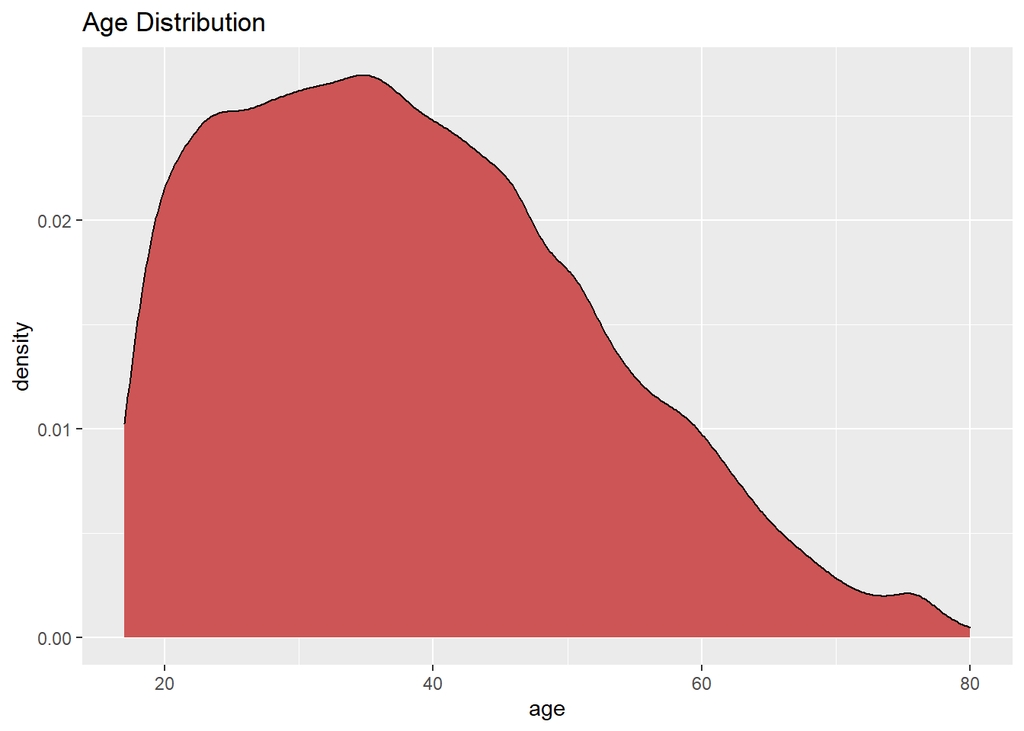

```r
#Density plot
ggplot(cens, aes(x = age)) +
  geom_density(fill = "indianred3") +
  labs(title = "Age Distribution")
```

```r
fitdistr(cens$age, "normal")
```

```
##       mean           sd
##   38.54987252   13.54137901
##  ( 0.07505288) ( 0.05307040)
```

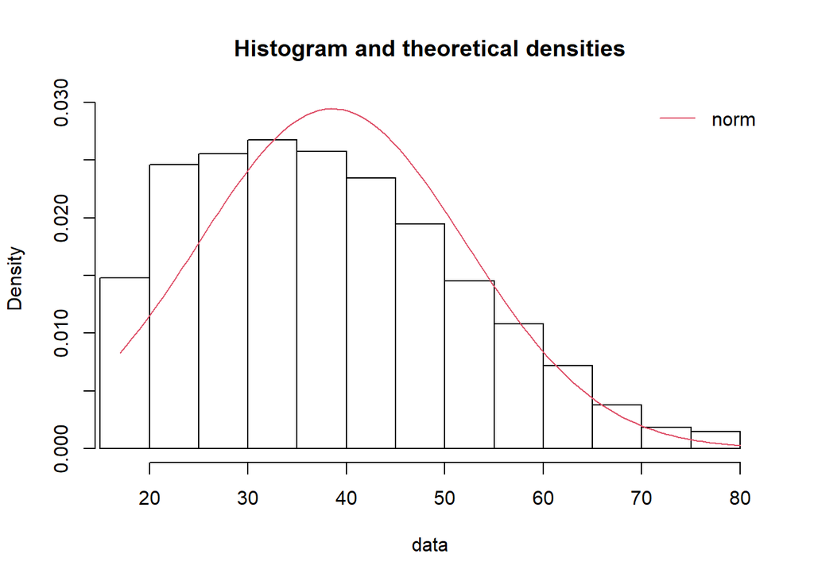

```r
discrete.age <- cens$age
#descdist(discrete.age, discrete = FALSE)
fit.norm <- fitdist(discrete.age, "norm")
denscomp(fit.norm)
```

## 2.2 Normalitat

Els intervals de confiança és una tècnica d’estimació que ens permeten acotar entre dos valors on es trobarà la mitjana poblacional fent ús de la mitjana mostral. És a dir, realitzem l’estimació del valor de tota la població, mitjançant l’ús d’una mostra significativa de valors de la població. En el nostre cas, podem assumir normalitat després d’observar la distribució del paràmetre ‘Age’, i com a tal calcular l’interval de confiança de la mitjana d’edat.

## 2.3 Interval de confiança

A continuació realitzem una funció anomenada IC que donat un vector de dades (x) i un nivell de confiança (NF), retorni els intervals de confiança de la mostra.

```r
IC <- function(x, NC) {
  n <- length(x)
  mean <- mean(x)
  sd <- sd(x)
  z <- abs(qnorm(((1-NC)/2)))
  errorst <- sd/sqrt(n)
  lim_inf <- mean - (z*errorst)
  lim_sup <- mean + (z*errorst)
  output <- data.frame(NC, n, mean, sd, z, errorst, lim_inf, lim_sup)
  return(output)
}
```

## 2.4 Càlculs

Calculem els intervals de confiança de la variable ‘Age’ mitjançant la funció creada a l’apartat anterior. A la vegada, realitzem la comprovació del correcte funcionament de la nostra funció mitjançant la qual disposa R anomenada t.test.

```r
IC(cens$age, 0.95)
```

```
##     NC     n     mean       sd        z    errorst  lim_inf  lim_sup
## 1 0.95 32553 38.54987 13.54159 1.959964 0.07505404 38.40277 38.69698
```

```r
IC(cens$age, 0.90)
```

```
##    NC     n     mean       sd        z    errorst  lim_inf  lim_sup
## 1 0.9 32553 38.54987 13.54159 1.644854 0.07505404 38.42642 38.67333
```

```r
t.test(cens$age, conf.level = 0.95)
```

```
##
##  One Sample t-test
##
## data:  cens$age
## t = 513.63, df = 32552, p-value < 2.2e-16
## alternative hypothesis: true mean is not equal to 0
## 95 percent confidence interval:
##  38.40276 38.69698
## sample estimates:
## mean of x
##  38.54987
```

```r
t.test(cens$age, conf.level = 0.90)
```

```
##
##  One Sample t-test
##
## data:  cens$age
## t = 513.63, df = 32552, p-value < 2.2e-16
## alternative hypothesis: true mean is not equal to 0
## 90 percent confidence interval:
##  38.42642 38.67333
## sample estimates:
## mean of x
##  38.54987
```

Podem observar que els resultats obtinguts d’ambdues funcions és el mateix utilitzant dos nivells de confiança diferents.

## 2.5 Interpretació

Els intervals de confiança ens permeten establir entre quins valors es trobarà la mitjana d’edat amb un percentatge concret de confiança. Així doncs, utilitzant el nivell de confiança del 95%, podem determinar que la mitjana d’edat es trobarà entre 38.4 i 38.7 anys, és a dir, en 38 anys.

# 3 Salari

En aquest apartat realitzarem un estudi de la variable ‘income’, que recordem es troba en milers d’euros (k€) com a unitat.

## 3.1 Pregunta de recerca

La pregunta formulada és que si el salari promig de les persones Self-Employed és inferior al salari promig al de la resta de modalitats.

## 3.2 Hipòtesi

Un cop formulada la pregunta que desitgem respondre, cal determinar la hipòtesi nul·la i la hipòtesi alternativa.

$$H_0: \mu _S <\mu_O$$

$$H_1: \mu _S \geq \mu_O$$

La primera de les dues, la hipòtesi nul·la, representa allò que desitgem provar. En aquest cas, el que volem provar és que el salari de la gent Self-Employed, representat mitjançant
$$\mu _S$$
, de forma mitjana, és inferior al salari de les altres modalitats. Representat mitjançant:
$$\mu _0$$

Mentre que la segona, la hipòtesi alternativa, és aquella que oferim com a alternativa a la nul·la. En aquest cas, la hipòtesi alternativa indica que el salari de la gent Self-Employed en promig, és igual o major que el de la gent d’altres modalitats.

## 3.3 Test a aplicar

Per saber quin tipus de test podem aplicar per resoldre la pregunta plantejada i les caracteristiques de la mostra, realitzarem un petit estudi sobre el conjunt de dades.

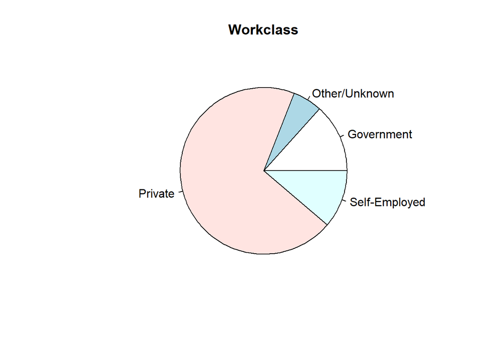

```r
#Grafic
pie(table(cens$workclass), main="Workclass")
```

```r
#SelfEmployed DF and nrows
selfemployed <- cens %>% filter(workclass == "Self-Employed")
selfemployed.nrow <- nrow(selfemployed)
print(paste("Self-Employed is a ", (selfemployed.nrow/(nrow(cens))) *100, "% of the set"))
```

```
## [1] "Self-Employed is a  11.2339876509077 % of the set"
```

En primer lloc, observem quina és la proporció de la mostra que correspon a la gent de tipus Self-Employed. Aquestes corresponen un total de 3657 de registres, que suposen un 11.23 % de la mostra. A continuació visualitzarem la distribució dels salaris, el grup que són Self-Employed i el de les altres modalitats.

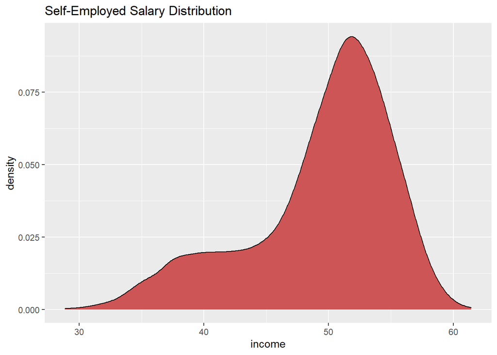

```r
#Self-Employed
##Grafic
ggplot(selfemployed, aes(x = income)) +
  geom_density(fill = "indianred3") +
  labs(title = "Self-Employed Salary Distribution")
```

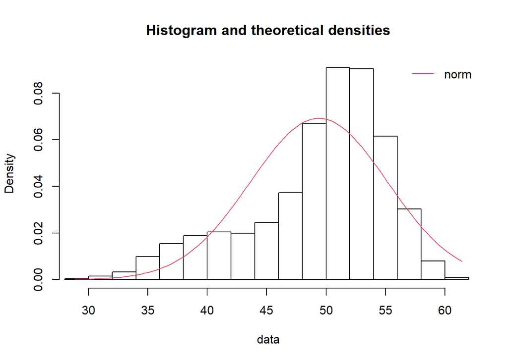

```r
selfemployed.discrete.income <- selfemployed$income
fit.norm <- fitdist(selfemployed.discrete.income, "norm")
denscomp(fit.norm)
```

```r
## Mean and sd
selfemployed.salary.mean <- mean(selfemployed$income)
print(selfemployed.salary.mean)
```

```
## [1] 49.39123
```

```r
selfemployed.salary.sd <- sd(selfemployed$income)
print(selfemployed.salary.sd)
```

```
## [1] 5.763864
```

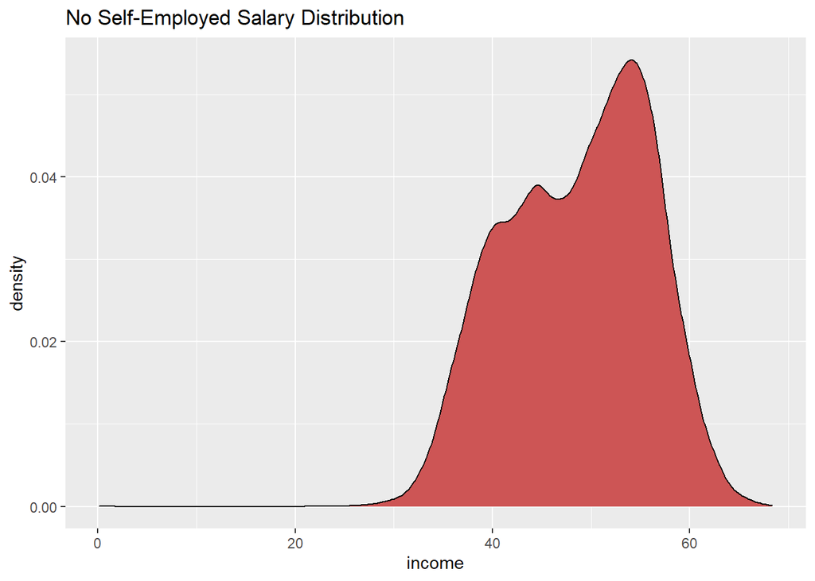

```r
#No Self-Employed
##Grafic
noselfemployed <- cens %>% filter(workclass != "Self-Employed")
ggplot(noselfemployed, aes(x = income)) +
  geom_density(fill = "indianred3") +
  labs(title = "No Self-Employed Salary Distribution")
```

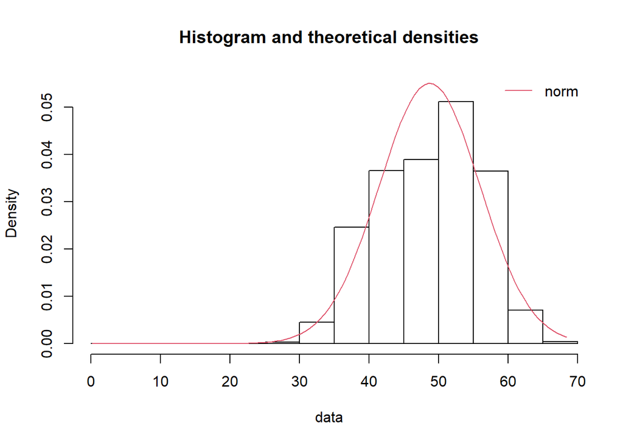

```r
noselfemployed.discrete.income <- noselfemployed$income
fit.norm <- fitdist(noselfemployed.discrete.income, "norm")
denscomp(fit.norm)
```

```r
## Mean and sd
noselfemployed.salary.mean <- mean(noselfemployed$income)
print(noselfemployed.salary.mean)
```

```
## [1] 48.67183
```

```r
noselfemployed.salary.sd <- sd(noselfemployed$income)
print(noselfemployed.salary.sd)
```

```
## [1] 7.247907
```

## 3.4 Càlcul

```r
pValueContrast <- function(x, population_mean, NC){
  alpha <-(1-NC)
  print(c(-qnorm(alpha/2, lower.tail = FALSE), qnorm(alpha/2, lower.tail = FALSE))) #Regió acceptació
  n<-length(x)
  mean<-mean(x)
  sd<-sd(x)
  t <- (mean-population_mean)/(sd/sqrt(n))
  pvalue <- 2*pt(-abs(t), df = n-1)
  pvalue
}
cens.income.mean <- mean(cens$income)
pValueContrast(selfemployed$income, cens.income.mean,0.95)
```

```
## [1] -1.959964  1.959964
```

```
## [1] 2.407595e-11
```

```r
pValueContrast(selfemployed$income, cens.income.mean,0.90)
```

```
## [1] -1.644854  1.644854
```

```
## [1] 2.407595e-11
```

# 4 Resum i conclusions

[output not shown]